# MATH 216 Homework 3 Principles

Albert Y. Kim

# Load Packages and Data

```r
library(ggplot2)
library(dplyr)
library(broom)

profiles <- readr::read_csv(file="profiles.csv") %>%
  filter(!is.na(height)) %>%
  mutate(is_female=ifelse(sex=='f', 1, 0)) %>%
  tibble::rownames_to_column(var="id")
```

We going to use `age` and `drugs` as the predictor variables.

# Missing Data

At the very least, for each of the predictor variables we use, we need to address rows (i.e. individuals) with missing values `NA`. Otherwise, no predictions will be returned (see below). For example a proportion 0.235 of `drugs` values are `NA` missing; we can’t not return a prediction for this many people! So we change the `NA`s to an actual level of the categorical variable drugs. Note this is clumsy is we are losing any discriminative information about the sexes contained for those users that did respond!

```r
profiles <- profiles %>%
  mutate(drugs = ifelse(is.na(drugs), "did not report", drugs))
```

# Split into Training and Test Data

You need to split the training (2997 rows) and test (56946 rows) data into two **disjoint** data sets. For example here is one not-so-great way. Ask yourself, why is this approach suspect?

```r
training <- profiles %>%
  slice(1:2997)
test <- profiles %>%
  slice(2998:59943)
```

# Conceptual Leap Necessary

For this exercise to have been completely realistic, for both HW-2 (EDA) and HW-3 (predictive modeling) I should have:

- For `training`, given you both
  - The predictor variables: `age` and `drugs`
  - The “truth” variable: `is_female`
- For `test` **only** given you the predictor variables: `age` and `drugs`

Then the exercise would proceed as follows:

- You would train your model by fitting a logistic regression model `predict_sex_model` to `training`
- Then, using `test`
  - Fit `predict_sex_model` on `test` **which only has the predictor variables, not the truth variable** (as we do below using the `predict()` function)
  - Which then returns a fitted probability `p_hat` of being female for all 56946 `test` users
  - Which you would then convert to a predicted sex in a variable `predicted_female`
  - Which you would then send to me
- Since only I would know the truth in `is_female`, only I could tell you what proportion of the 56946 users you guessed correct! This is how [Kaggle competitions](https://www.kaggle.com/competitions) work!

Alas, this only occurred to me after it was too late. So to salvage what I could from this exercise, I have set up this work around where:

- You need to **pretend hide** the truth variable variable from yourself in `test`. i.e. pretend like I never gave you the true sex, as reflected in `is_female`, in `test`.
- Hence you, instead of me behind the scenes, will evaluate how well your predictions fared after **pretend unveiling** the truth to yourself.

# Train the Model

When training the model, we have access to both:

- The predictor variables: `age` and `drugs`
- The truth variable: `is_female`

i.e. We have this:

```r
training %>%
  select(age, drugs, is_female) %>%
  View()
```

| age | drugs | is_female |
| --- | --- | --- |
| 22 | never | 0 |
| 35 | sometimes | 0 |
| 38 | did not report | 0 |
| 23 | did not report | 0 |
| 29 | never | 0 |

We then fit a logistic regression using `training`:

```r
predict_sex_model <- glm(is_female ~ age + drugs, data=training, family="binomial")
```

# Test the Model

As mentioned above, we at first **pretend hide** the truth variable `is_female` i.e. pretend I never gave it to you:

```r
test %>%
  select(age, drugs) %>%
  View()
```

| age | drugs |
| --- | --- |
| 32 | did not report |
| 24 | did not report |
| 28 | never |
| 25 | did not report |
| 25 | did not report |

We take the trained model `predict_sex_model`, apply it to predictor variables `age` and `drugs` in `test`, and obtain 56946 fitted probabilities `p_hat` of being female using the `predict()` function. **Note**: if any of `age` and `drugs` were `NA` missing, NO value would be returned for that user, and hence `p_hat` would be of length less than 56946.

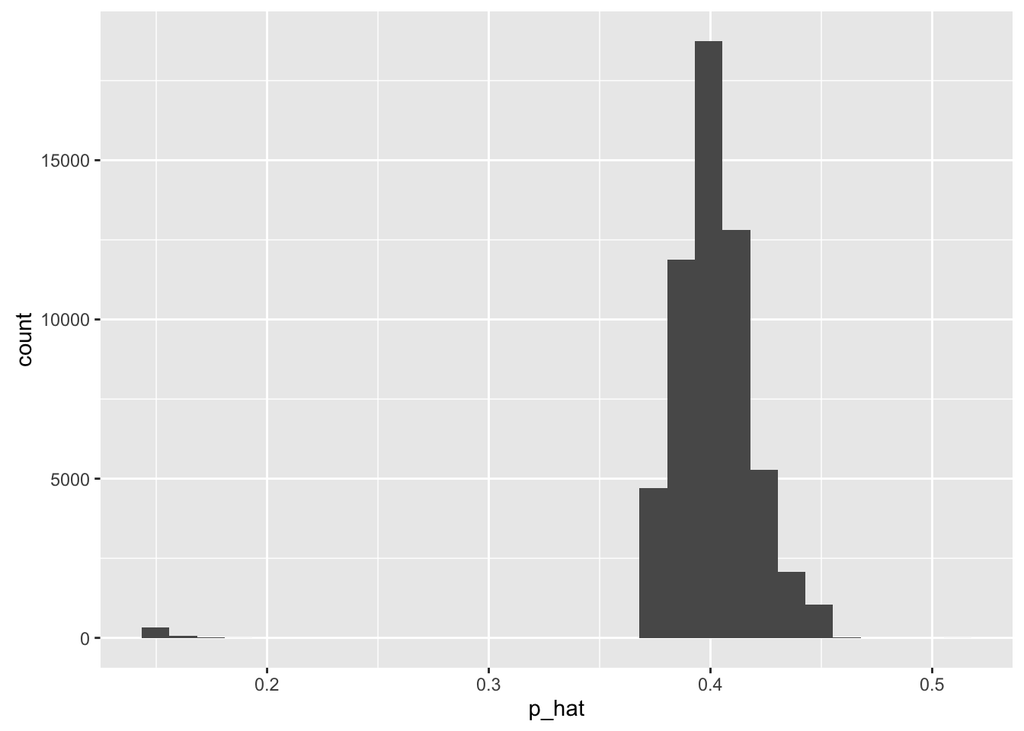

```r
p_hat <- predict(predict_sex_model, newdata=test, type="response")
ggplot(data=NULL, aes(x=p_hat)) +
  geom_histogram()
```

Following tidy data principles (variables describing the same observational units should be kept in the same data frame) we add these predictions to our `test` data set via a `mutate()`.

```r
test <- test %>%
  mutate(p_hat = predict(predict_sex_model, newdata=test, type="response"))
```

So what we now have is:

```r
test %>%
  select(age, drugs, p_hat) %>%
  View()
```

| age | drugs | p_hat |
| --- | --- | --- |
| 32 | did not report | 0.3900222 |
| 24 | did not report | 0.3799643 |
| 28 | never | 0.4029798 |
| 25 | did not report | 0.3812161 |
| 25 | did not report | 0.3812161 |

Now you **pretend unveil** the truth variable `is_female` to yourself, allowing you to evaluate for yourself (and not me from behind the curtains) how well your prediction mechanism fared:

```r
test %>%
  select(age, drugs, p_hat, is_female) %>%
  View()
```

| age | drugs | p_hat | is_female |
| --- | --- | --- | --- |
| 32 | did not report | 0.3900222 | 1 |
| 24 | did not report | 0.3799643 | 1 |
| 28 | never | 0.4029798 | 0 |
| 25 | did not report | 0.3812161 | 1 |
| 25 | did not report | 0.3812161 | 1 |